# Medicare data challenge

## 3.4 EDA of some influencing factors

From my own experience, I choosed some factors that I think are not neglectable. And I will be plot a graph hopinng it will show the relationship of the star rating and the factors.

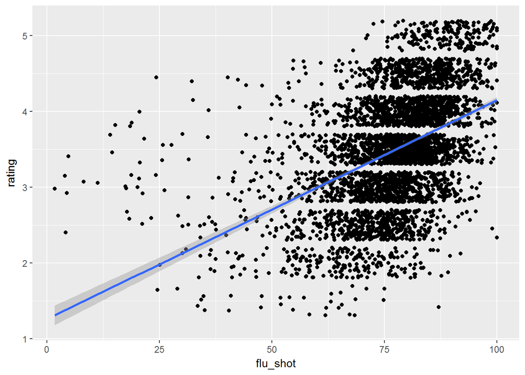

```r
ggplot(hca,aes(x=flu_shot,y=rating))+geom_jitter()+geom_smooth(method = "lm")
```

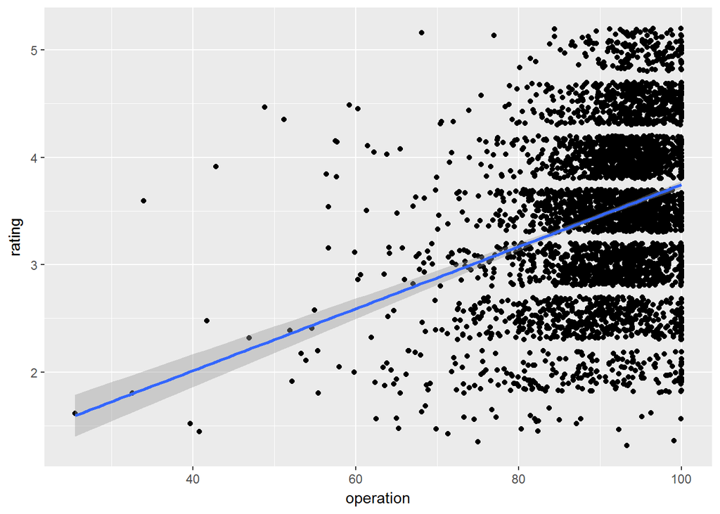

```r
ggplot(hca,aes(x=operation,y=rating))+geom_jitter()+geom_smooth(method = "lm")
```

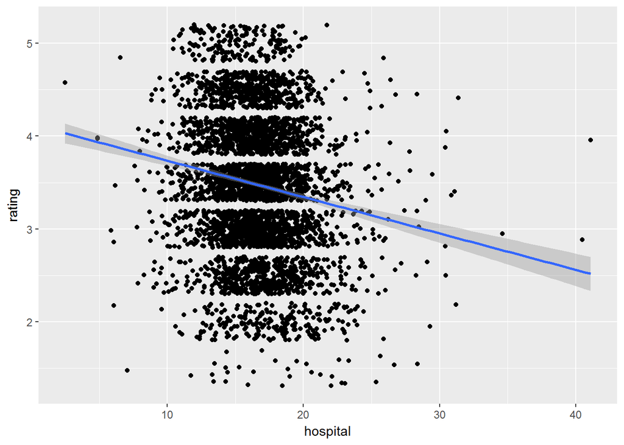

```r
ggplot(hca,aes(x=hospital,y=rating))+geom_jitter()+geom_smooth(method = "lm")
```

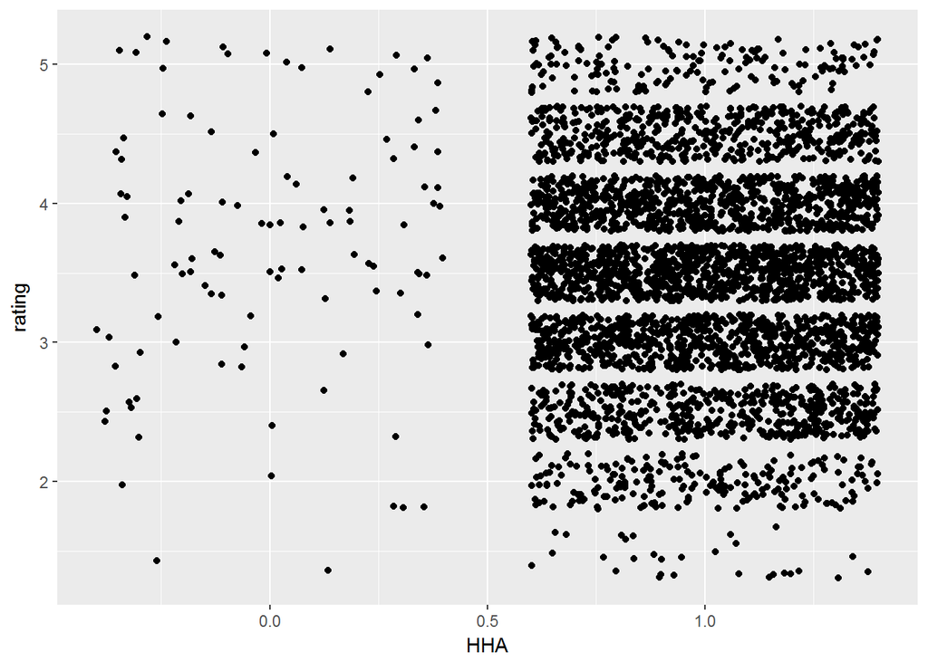

```r
ggplot(hca,aes(x=HHA,y=rating))+geom_jitter()
```

# 4. Multilevel Modeling

## 4.1 random intercept

To find the good model fit, I will be playing around with the dataset first and fitting lots of models to try to find the great model fit.

```r
library(lme4)
fit1<-lmer(rating~flu_shot+operation+hospital+(1|state),data=hca)
summary(fit1)
```

```
## Linear mixed model fit by REML ['lmerMod']
## Formula: rating ~ flu_shot + operation + hospital + (1 | state)
##    Data: hca
##
## REML criterion at convergence: 8121.5
##
## Scaled residuals:
##     Min      1Q  Median      3Q     Max
## -3.3392 -0.6841 -0.0149  0.6683  4.1260
##
## Random effects:
##  Groups   Name        Variance Std.Dev.
##  state    (Intercept) 0.09802  0.3131
##  Residual             0.37888  0.6155
## Number of obs: 4257, groups:  state, 53
##
## Fixed effects:
##               Estimate Std. Error t value
## (Intercept) -0.0021030  0.1457654   -0.01
## flu_shot     0.0313764  0.0008558   36.66
## operation    0.0194056  0.0013107   14.81
## hospital    -0.0420071  0.0032133  -13.07
##
## Correlation of Fixed Effects:
##           (Intr) fl_sht opertn
## flu_shot  -0.338
## operation -0.749 -0.146
## hospital  -0.376  0.019  0.000
```

```r
fit2<-lmer(rating~flu_shot+operation+hospital+HHA+(1|state),data=hca)
summary(fit2)
```

```
## Linear mixed model fit by REML ['lmerMod']
## Formula: rating ~ flu_shot + operation + hospital + HHA + (1 | state)
##    Data: hca
##
## REML criterion at convergence: 8113.4
##
## Scaled residuals:
##     Min      1Q  Median      3Q     Max
## -3.3337 -0.6821 -0.0182  0.6711  4.1295
##
## Random effects:
##  Groups   Name        Variance Std.Dev.
##  state    (Intercept) 0.09882  0.3144
##  Residual             0.37787  0.6147
## Number of obs: 4257, groups:  state, 53
##
## Fixed effects:
##               Estimate Std. Error t value
## (Intercept)  0.2098748  0.1580791    1.33
## flu_shot     0.0313417  0.0008548   36.66
## operation    0.0193210  0.0013092   14.76
## hospital    -0.0418862  0.0032093  -13.05
## HHA         -0.2083542  0.0603859   -3.45
##
## Correlation of Fixed Effects:
##           (Intr) fl_sht opertn hosptl
## flu_shot  -0.316
## operation -0.697 -0.146
## hospital  -0.342  0.018  0.000
## HHA       -0.389  0.014  0.018 -0.012
```

```r
AIC(fit1,fit2)
```

```
##      df      AIC
## fit1  6 8133.507
## fit2  7 8127.394
```

```r
fit3<-lmer(rating~flu_shot*state+operation+hospital+HHA+(1|state),data=hca)
```

```
## fixed-effect model matrix is rank deficient so dropping 1 column / coefficient
```

```r
fit4<-lmer(rating~flu_shot+operation*state+hospital+HHA+(1|state),data=hca)
```

```
## fixed-effect model matrix is rank deficient so dropping 1 column / coefficient
```

```r
fit5<-lmer(rating~flu_shot+operation+hospital*state+HHA+(1|state),data=hca)
```

```
## fixed-effect model matrix is rank deficient so dropping 1 column / coefficient
```

```r
fit6<-lmer(rating~flu_shot+operation+hospital+HHA*state+(1|state),data=hca)
```

```
## fixed-effect model matrix is rank deficient so dropping 23 columns / coefficients
```

```r
AIC(fit2,fit3,fit4,fit5,fit6)
```

```
##       df      AIC
## fit2   7 8127.394
## fit3 110 8518.945
## fit4 110 8547.065
## fit5 110 8485.972
## fit6  88 8213.892
```

Based on the AIC result, the best model fit is model fit2, including factors such as HHA, flu_shot, operation, hospital and the group variable state.

## 4.2 random slope

For the previous models that I fit, there are only random intercept effect. I picked the best model fit and now I will be fitting random slope models.

```r
fit7<-lmer(rating~flu_shot+operation+hospital+HHA+(1+hospital|state),data=hca)
fit8<-lmer(rating~flu_shot+operation+hospital+HHA+(1+HHA|state),data=hca)
fit9<-lmer(rating~flu_shot+operation+hospital+HHA+(1+operation|state),data=hca)
fit10<-lmer(rating~flu_shot+operation+hospital+HHA+(1+flu_shot|state),data=hca)
AIC(fit7,fit8,fit9,fit10)
```

```
##       df      AIC
## fit7   9 8127.701
## fit8   9 8130.838
## fit9   9 8121.358
## fit10  9 8051.309
```

```r
fit11<-lmer(rating~flu_shot+operation+hospital*state+HHA+(1+flu_shot|state),data=hca)
```

```
## fixed-effect model matrix is rank deficient so dropping 1 column / coefficient
```

```r
fit12<-lmer(rating~flu_shot+operation*state+hospital+HHA+(1+flu_shot|state),data=hca)
```

```
## fixed-effect model matrix is rank deficient so dropping 1 column / coefficient
```

```r
fit13<-lmer(rating~flu_shot*state+operation+hospital+HHA+(1+flu_shot|state),data=hca)
```

```
## fixed-effect model matrix is rank deficient so dropping 1 column / coefficient
```

```r
fit14<-lmer(rating~flu_shot+operation+hospital+HHA*state+(1+flu_shot|state),data=hca)
```

```
## fixed-effect model matrix is rank deficient so dropping 23 columns / coefficients
```

```r
AIC(fit10,fit11,fit12,fit13,fit14)
```

```
##        df      AIC
## fit10   9 8051.309
## fit11 112 8444.631
## fit12 112 8510.110
## fit13 112 8522.945
## fit14  90 8166.756
```

Based on the AIC result, the best model fit is model fit10, including factors such as HHA, flu_shot, operation, hospital and random slope group effect on flu shot.

Now, I have two good-fit models which are random intercept effect model and random slope effect model. For my next step, I will be doing some model checking.